# Forecasting future movement from speed trajectories in Roe Deer using a linear predictive model and time series analysis

## Speed forecasting

For the prediction of the velocities on the basis of a time model, the package “Prophet” (Taylor & Letham, 2021) was used, which creates a time model based on time data and a feature type, i.e. a variable, and on the basis of the seasonalities and fluctuations contained therein, creates a forecast of the values to be achieved. In this model, the speed for the next 24 hours was modeled, for each of the three deer separately. Further, a general trend was calculated by means of the model, which algorithmically analyzes the fluctuations of the days and weeks and creates a trend curve. The “speed forecasting” function used for this purpose calculates the average speed of each movement segment of the individual animals and predicts the next 24 hours of the animals’ speed by means of an additional data set with 24 periods. This results in an additional data set, with the upper and lower trend values of the already existing data and those in the future, which are supplemented with the uncertainty range of the respective predicted values.

## Roaming range estimation

From the forecast data of the time model, the upper and lower trend values of the forecasted 24h were used to predict the roaming-range, i.e. the possible residence areas of the animals. For this purpose, two areas were calculated: a minimum and a maximum distance which is possible for the animal on the basis of the forecast. The functions “min max” calculated first by means of the lower and upper prognosis border, the distance in meters, which the animal can reach, if it holds the prognosticated averaged speed over the next 24h. From the distance resulting from it by means of the function “roamingrange” a minimum and a maximum distance buffer were computed and assigned to the coordinates of the all last measurement.

In addition to the minimum and maximum velocity values calculated by the model, the trend value was also used to calculate a third distance value that best reflects the possible distance over time. These distance values are visualized in the following plot, where the minimum and maximum travel distance for the deer 1, 2 and 3 are shown and complemented by the trend values. Thus, the minimum distance is shown in green, the maximum distance value in red and the optimal trend value in blue.

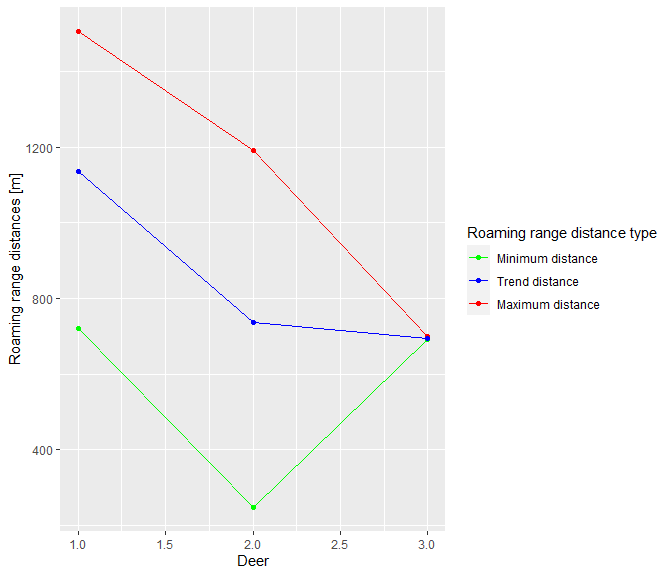

Fig. 1: Roaming distances for roe deer in the proximate future

## Linear predictive model

As a final methodological step for the analysis and prediction of deer velocities, linear models and a k-nearest-neighbor algorithm were used to determine the statistical relationship of velocity with the variables: “sex, distance between two measurement points, time difference, ground cover according to the Arealstatistik and the turning angle between to following trajectory segments. For the comparison of the velocity values among themselves and how they influence each other, the KNN algorithm was used and the velocity values were classified to determine if the velocity is autocorrelated or not, from the resulting data a further prediction of the velocity was derived to better assess the uncertainty of the previous linear models. To compare the different outputs of the KNN algorithm, a 10-fold cross-validation was performed, which compares the possible combinations of sample size and variables used and selects the best model. A seed was also set for this, as for the linear models, in order to obtain the same outputs of the models in further analyses.

# Results

## Time series

The following figures show the time series analysis for the three roe deer, implemented in a visualization of the observed values, versus the predicted values from the model, with the dark blue line indicating the predicted values, while the light blue area indicates the uncertainty area of the time series speed prediction. The output which was generated also shows the hourly but also weekly trends in the changes of the velocities, which allows a conclusion on a possible behavioral pattern of the animals.

When analyzing the results of the time series, several clear patterns emerge. For example, none of the three-time series is the same in several aspects, suggesting that the animals moved independently since velocity distribution varies significantly among the three animals. While deer 1 and 2 show a very constant velocity over time (Figure 2 and 3), with only two outliers where the velocity increased markedly, the velocity of deer 3 (Figure 4) is much more fluctuating and varies massively over time than that of the other animals. Only the time series of the second animal shows two jumps in the speed with the temporary increase of the speed, which is not the case with the first animal. The same pattern as in the time analysis shows up in the trend of the values, so the trend of the animal 2 is jumpy big and again small in summer and winter 2014, while the enormously increasing speed of the first animal shows up with an increasing trend for the two outliers in October of the same year. Further, it can be noted that the fluctuations and changes daily and weekly do not follow the same pattern for all three animals. All are mainly active at different times and not on the same days of the week. The second animal increased in the evening fast on the move, while the other two deer are alternately active throughout the day and increased at midday and morning hours. The trend of the third animal also deviates strongly from the other animals, where this was in the summer in each case strongly more slowly, i.e., less on the way than the two other animals.

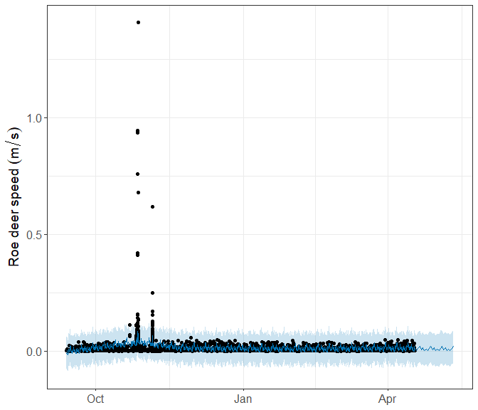

Fig. 2: Time series speed predction for roe deer #1

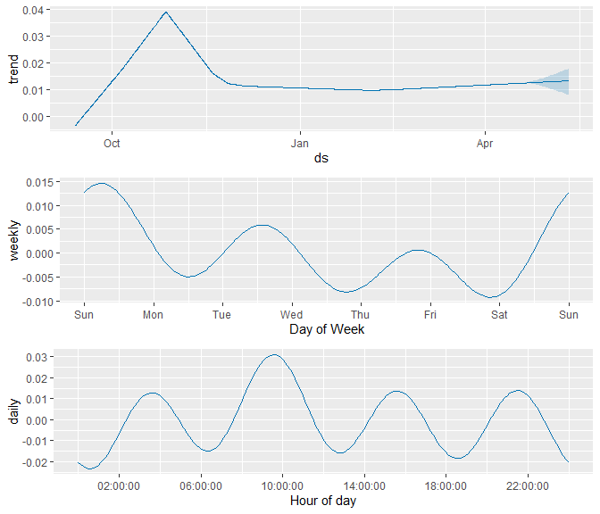

Fig. 2: Time series speed predction for roe deer #1

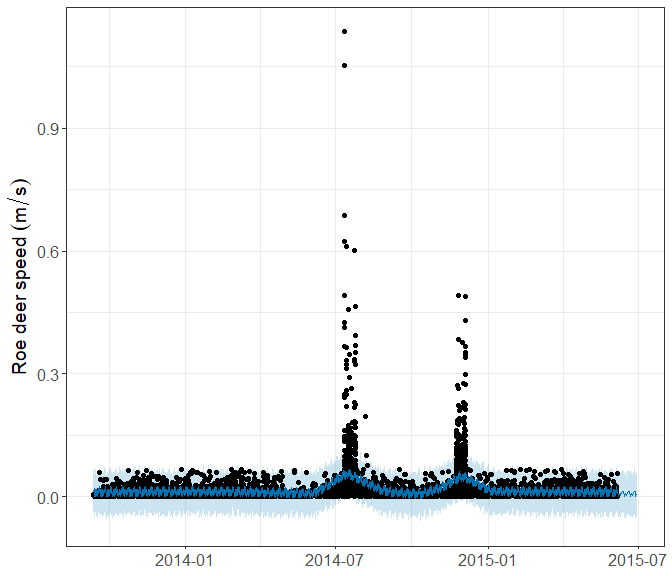

Fig. 3: Time series speed predction for roe deer #2

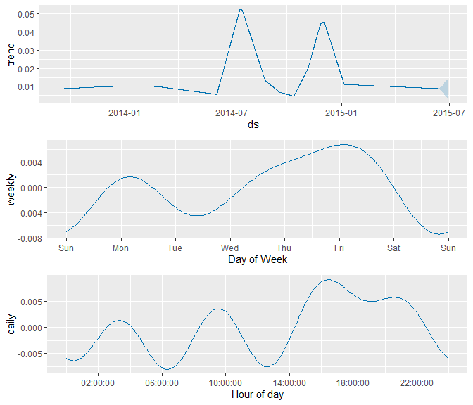

Fig. 3: Time series speed predction for roe deer #2

[figure not shown]

[figure not shown]

## Change points and travel distance prognosis

Comparing the time series of the three deer, which show strongly varying and different patterns, the results of the changepoint analyses are exceptionally homogeneous and deviate minimally from each other. All three-time series show no significant changes in velocity and, therefore, no changepoints, i.e., moments in the time series where the velocity has changed abruptly. Thus, the BIC (Bayesian Information Criterion) for all three changepoint models is between 20 and 30 and, accordingly, very small. These values indicate that the time series, i.e., the model, has analyzed the velocity very poorly; thus, the error range is extensive. This is even more significant as the time travel from the above section has shown an opposite picture, and the plot of the velocities show massive differences over time, which should have been reflected in the changepoint analysis, but is not the case, but can be explained by the low MBIC values because the model is fragile. Thus, it would have been expected that a changepoint would have occurred at least at those points where the CPT model shows a trend change in the time series and the trend values change abruptly in the short term.

```
## Class 'cpt' : Changepoint Object
##        ~~   : S4 class containing 14 slots with names
##               cpts.full pen.value.full data.set cpttype method test.stat pen.type pen.value minseglen cpts ncpts.max param.est date version
##
## Created on  : Fri Jun 24 16:09:27 2022
##
## summary(.)  :
## ----------
## Created Using changepoint version 2.2.3
## Changepoint type      : Change in mean
## Method of analysis    : BinSeg
## Test Statistic  : Normal
## Type of penalty       : MBIC with value, 22.66615
## Minimum Segment Length : 1
## Maximum no. of cpts   : 5
## Changepoint Locations :
## Range of segmentations:
##      [,1] [,2] [,3] [,4] [,5]
## [1,]    0   NA   NA   NA   NA
## [2,]    0    0   NA   NA   NA
## [3,]    0    0    0   NA   NA
## [4,]    0    0    0    0   NA
## [5,]    0    0    0    0    0
##
##  For penalty values: 0 0 0 0 0
```

```
## numeric(0)
```

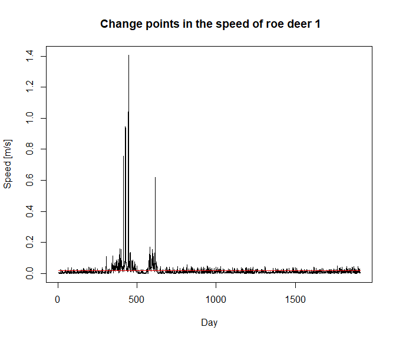

```
## Class 'cpt' : Changepoint Object
##        ~~   : S4 class containing 14 slots with names
##               cpts.full pen.value.full data.set cpttype method test.stat pen.type pen.value minseglen cpts ncpts.max param.est date version
##
## Created on  : Fri Jun 24 16:09:27 2022
##
## summary(.)  :
## ----------
## Created Using changepoint version 2.2.3
## Changepoint type      : Change in mean
## Method of analysis    : BinSeg
## Test Statistic  : Normal
## Type of penalty       : MBIC with value, 26.0527
## Minimum Segment Length : 1
## Maximum no. of cpts   : 5
## Changepoint Locations :
## Range of segmentations:
##      [,1] [,2] [,3] [,4] [,5]
## [1,]    0   NA   NA   NA   NA
## [2,]    0    0   NA   NA   NA
## [3,]    0    0    0   NA   NA
## [4,]    0    0    0    0   NA
## [5,]    0    0    0    0    0
##
##  For penalty values: 0 0 0 0 0
```

```
## numeric(0)
```

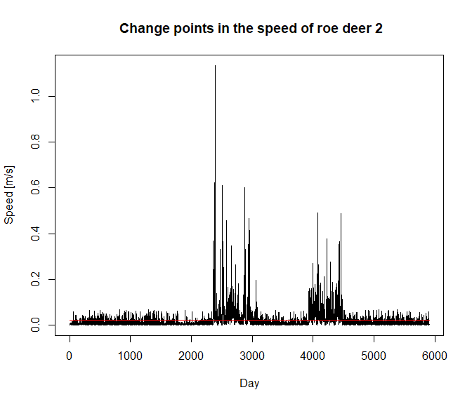

```
## Class 'cpt' : Changepoint Object
##        ~~   : S4 class containing 14 slots with names
##               cpts.full pen.value.full data.set cpttype method test.stat pen.type pen.value minseglen cpts ncpts.max param.est date version
##
## Created on  : Fri Jun 24 16:09:27 2022
##
## summary(.)  :
## ----------
## Created Using changepoint version 2.2.3
## Changepoint type      : Change in mean
## Method of analysis    : BinSeg
## Test Statistic  : Normal
## Type of penalty       : MBIC with value, 25.72299
## Minimum Segment Length : 1
## Maximum no. of cpts   : 5
## Changepoint Locations :
## Range of segmentations:
##      [,1] [,2] [,3] [,4] [,5]
## [1,]    0   NA   NA   NA   NA
## [2,]    0    0   NA   NA   NA
## [3,]    0    0    0   NA   NA
## [4,]    0    0    0    0   NA
## [5,]    0    0    0    0    0
##
##  For penalty values: 0 0 0 0 0
```

```
## numeric(0)
```

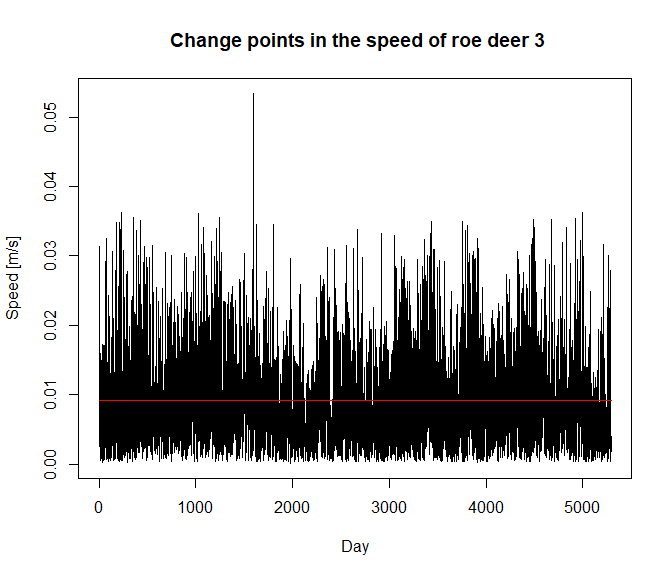

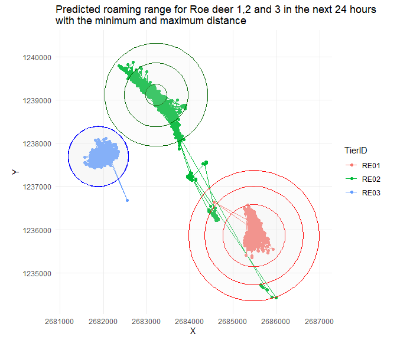

## Linear model evaluation

```
##
## Call:
## lm(formula = speed ~ sex + timelag + x + y + steplength + astk +
##     angle, data = deer_cleaned)
##
## Residuals:
##      Min       1Q   Median       3Q      Max
## -0.43386 -0.00463 -0.00098  0.00102  3.14555
##
## Coefficients:
##               Estimate Std. Error  t value Pr(>|t|)
## (Intercept)  2.084e+00  3.795e-01    5.492 3.99e-08 ***
## sex         -4.632e-04  3.170e-04   -1.461    0.144
## timelag     -6.210e-06  3.623e-08 -171.403  < 2e-16 ***
## x           -4.994e-07  1.137e-07   -4.393 1.12e-05 ***
## y           -5.520e-07  7.494e-08   -7.366 1.78e-13 ***
## steplength   1.225e-04  1.260e-06   97.187  < 2e-16 ***
## astk         7.957e-05  1.553e-05    5.124 3.00e-07 ***
## angle       -3.048e-05  7.359e-05   -0.414    0.679
## ---
## Signif. codes:  0 '***' 0.001 '**' 0.01 '*' 0.05 '.' 0.1 ' ' 1
##
## Residual standard error: 0.04033 on 80020 degrees of freedom
## Multiple R-squared:  0.2812, Adjusted R-squared:  0.2812
## F-statistic:  4473 on 7 and 80020 DF,  p-value: < 2.2e-16
```

```
##
## Call:
## lm(formula = speed ~ astk, data = deer_cleaned)
##
## Residuals:
##     Min      1Q  Median      3Q     Max
## -0.0240 -0.0171 -0.0114  0.0002  3.1959
##
## Coefficients:
##               Estimate Std. Error t value Pr(>|t|)
## (Intercept)  2.408e-02  8.147e-04  29.557  < 2e-16 ***
## astk        -6.538e-05  1.689e-05  -3.871 0.000108 ***
## ---
## Signif. codes:  0 '***' 0.001 '**' 0.01 '*' 0.05 '.' 0.1 ' ' 1
##
## Residual standard error: 0.04757 on 80026 degrees of freedom
## Multiple R-squared:  0.0001873,  Adjusted R-squared:  0.0001748
## F-statistic: 14.99 on 1 and 80026 DF,  p-value: 0.0001083
```

```
##
## Call:
## lm(formula = speed ~ sex, data = deer_cleaned)
##
## Residuals:
##     Min      1Q  Median      3Q     Max
## -0.0218 -0.0171 -0.0113  0.0001  3.1964
##
## Coefficients:
##               Estimate Std. Error t value Pr(>|t|)
## (Intercept)  0.0219086  0.0002606  84.066  < 2e-16 ***
## sex         -0.0015681  0.0003411  -4.597 4.29e-06 ***
## ---
## Signif. codes:  0 '***' 0.001 '**' 0.01 '*' 0.05 '.' 0.1 ' ' 1
##
## Residual standard error: 0.04756 on 80026 degrees of freedom
## Multiple R-squared:  0.000264,   Adjusted R-squared:  0.0002515
## F-statistic: 21.13 on 1 and 80026 DF,  p-value: 4.287e-06
```